# BUDT 758X - Data Processing and Analysis in Python

# Final Report - Group 47

### Lingtian He, Zhenhao Chen, Tong Cheng

# Project Description

## Overall Project Objectives

The project is focused on the analysis of **CS:GO**(Counter Strike: Global Offensive), a popular first-person-shooting online video game.

Since each player could utilize multiple weapons and grenades, choose the route to move on, stay in the site to fire or hide, and make different decisions, we would like to analyze the data to provide the useful strategies under different conditions: the weapon buying strategies at the beginning of each round, positioning strategies when starting to fight and bombing planting strategies.

### So the project aims to analyze and answer the following question statement:

- What are the different preference between common players and professional players, considering to analyze the weapon preference, grenade preference, hixbox, attacking position, and smoke land position under different situations?
- What are the factors which influence the winning probability of Counterterrorist and Terrorist? Does the type of round, the bombing planting, team wealth are important elements to win?
- What are the recommended strategy for Counterterrorist and Terrorist, considering weapon buying strategies, positioning strategies when starting to fight and bombing planting strategies?

## Description of Data

The whole dataset contains the overall and detailed information of 14921 ESEA matches, and the data of map. The dataset of match is initially separated by 2 parts, and each part has the independent files of basic information data, damage data, grenade data and kill data.

- [1] **Metadata** file(*basic information*): ‘esea_meta_demos’ contains per round meta information.
- [2] **Damage** file: ‘Esea_master_dmg_demos’, each row documents is an event when a player is hurt by another player.
- [3] **Grenade** file: ‘esea_master_grenades_demos’ contains a grenade thrown entry no matter whether the grenade causes damage.
- [4] **Kill** file: ‘esea_master_kills_demos’, each row is a kill entry.
- [5] **Map** file: ‘map_data.csv’ includes 7 official radar maps, which specifies in-game coordinates to aid in mapping data over them.

The dataset is obtained from Kaggle Dataset ‘CS:GO Competitive Matchmaking Data’. It can be found [here](https://www.kaggle.com/skihikingkevin/csgo-matchmaking-damage).

## The Summaried Appoarch of Proprocess and Analysis

The analysis mainly focus on the map 'dust II' (filename de_dust2), a classical and popular map in csgo.

**Preprocessing:**

In the preprocess stage, we have selected, filtered, cleaned, aggregated and converted the dataset, in detail:

1. merge the specific data (damage, kill, grenade) with basic data (metadata), because we have 7 independent dataset and we have to join them together for further analysis.
2. concatenate these 2 parts for each merged dataset(dmg, kill, grenade), since the data of matches has been separated into 2 parts.
3. drop several useless columns: the map that the match was played on, the current tick in the demo the entry took place, the steam id of the attacker and the victim, the new rank of the attacking player and victim after the match is complete.
4. create 3 new columns('seconds', 'wp_side', 'pro_game') for dmg dataset and 1 new column('seconds') for grenade dataset
   - 'seconds' indicates the time in seconds at which the damage or grenade happens in each round
   - 'wp_side' indicates whether the weapon is only available for ct(counterterrorist) or for t(terrorist)
   - 'pro_game' indicates whether it is a pro game
5. represent the numeric data in a reasonable way. Some values in the column 'ct_alive' and 't_alive', the columns showing the total number of survivors for either CT(Counter Terrorist) or T(Terrorist), are negative. Negativity actually means the total number of the dead. We convert the negative number to positive number by adding 5 to the negative value, because the total number of player in either CT or T is 5.
6. fill the missing value. Since CT can not plant the bomb in every round, the site where the bomb is planted will not be recorded for this round. So we replace the Nan value with 'Not Plant'.
7. create a dataframe for the analysis of the winning probability. After merging, we have 3 dataframes, but the information for what we need is diepersive and has to be collected, aggregated, and summarized.

**Analysis:**

1. we have compared the professional player and common player in the weapon preference. Separate the dataset into professional player and commpn player, we made the subplots for clear comparison. And we analyzed the weapon preference on the following 3 parts by histogram.
   - on the general type(Rifle, Pistol, Sniper, Heavy, SMG, Grenade, Equipment)
   - on the detailed type
   - on the detailed type by general category
2. we have compared the professional player and common player in hitbox, since pro players are expected to perform better than common players and hitbox could be a good measurement. For analysis, we use counterplot. However, the result is not what we expected, which actually shows that most damage is made on chest for common players while ‘generic’ is the biggest part for pro players. We think it might be an issue with grenade damage, so we eliminate grenade damage for pro players. However, things don’t change much, so we eliminate weapon ‘Unknown’. And then the performance looks similar for common players and pro players.
3. we have made heatmaps using seaborn kdeplot for revealing both sides' strategy and providing recommendations, especially focusing on attacking position under different scenarios:
   - Attacking position
   - Attacking position during pistol round
   - Attacking position for sniper
   - Grenade landing position
   - Attacking position under counter-terrorists eco-advantage round
   - Attacking position under terrorists eco-advantage round
4. we have worked out the winning probability affected by the site where bomb is planted, considering both CT side and T side.
5. after combing all the useful information(type of round and team wealth from metadata, the bombing planting from damage data, number of survivors from kill data), we figured out how the winning probabilty would be affected by type of round, the bombing planting and team wealth.

## Project Demonstration (in code)

```python
import pandas as pd
import numpy as np
import matplotlib.pyplot as plt
import seaborn as sns
%matplotlib inline
import warnings
warnings.simplefilter('ignore')
pd.set_option('display.max_columns',50)
pd.set_option('display.max_rows',200)
```

### Preprocessing data

#### 1.We input the data downloaded from Kaggle, and choose the map dust2.

```python
path='/Users/chengtong/Desktop/Project_Group 47_csgo/code/'
#path='/Users/andychen/Desktop/UMD/Spring 2019/Data Processing and Analysis in Python （BUDT758X)/Project/Data/csgo-matchmaking-damage/'
```

```python
meta_1=pd.read_csv(path+'esea_meta_demos.part1.csv')
meta_1=meta_1[meta_1.map=='de_dust2']
meta_2=pd.read_csv(path+'esea_meta_demos.part2.csv')
meta_2=meta_2[meta_2.map=='de_dust2']

kill_1=pd.read_csv(path+'esea_master_kills_demos.part1.csv')
kill_2=pd.read_csv(path+'esea_master_kills_demos.part2.csv')
dmg_1=pd.read_csv(path+'esea_master_dmg_demos.part1.csv')
dmg_2=pd.read_csv(path+'esea_master_dmg_demos.part2.csv')
grenade_1=pd.read_csv(path+'esea_master_grenades_demos.part1.csv')
grenade_2=pd.read_csv(path+'esea_master_grenades_demos.part2.csv')
```

#### 2.We merge all the separated dataset with Metadata.

The basic information as mentioned is in the file called 'esea_meta_demos'. In order to connect other data(damage, grenade and kill) with basic information of every match, we inner join the data on column 'file' and 'round'. Since the whole dataset, all the matches, has been separated into part1 and part2, we have to combine them together.

```python
#inner join the kill data with meta data
kill_1=meta_1.merge(kill_1, how='inner', on=['file','round'])
kill_2=meta_2.merge(kill_2, how='inner', on=['file','round'])
kill=pd.concat([kill_1, kill_2]) #concatenate part1 and part2

#inner join the damage data with meta data
dmg_1=meta_1.merge(dmg_1,how='inner',on=['file','round'])
dmg_2=meta_2.merge(dmg_2,how='inner',on=['file','round'])
dmg=pd.concat([dmg_1,dmg_2]) #concatenate part1 and part2

#inner join the grenade data with meta data
grenade_1=meta_1.merge(grenade_1,how='inner',on=['file','round'])
grenade_2=meta_2.merge(grenade_2,how='inner',on=['file','round'])
grenade=pd.concat([grenade_1,grenade_2]) #concatenate part1 and part2
```

This is the **Metadata** (basic information of each round).

```python
meta_1.head()
```

|  | file | map | round | start_seconds | end_seconds | winner_team | winner_side | round_type | ct_eq_val | t_eq_val |
| --- | --- | --- | --- | --- | --- | --- | --- | --- | --- | --- |
| 741 | esea_match_13779825.dem | de_dust2 | 1 | 131.3593 | 233.1502 | Team 1 | CounterTerrorist | PISTOL_ROUND | 4400 | 3700 |
| 742 | esea_match_13779825.dem | de_dust2 | 2 | 233.1502 | 296.1376 | Team 1 | CounterTerrorist | ECO | 18700 | 4050 |
| 743 | esea_match_13779825.dem | de_dust2 | 3 | 296.1376 | 373.3534 | Team 1 | CounterTerrorist | ECO | 22100 | 1600 |
| 744 | esea_match_13779825.dem | de_dust2 | 4 | 373.3534 | 614.6275 | Team 2 | Terrorist | NORMAL | 28250 | 20650 |
| 745 | esea_match_13779825.dem | de_dust2 | 5 | 614.6275 | 671.1659 | Team 1 | CounterTerrorist | FORCE_BUY | 10250 | 21150 |

This is the **Damage data** merged with Metadata, each row documents is an event when a player is hurt by another player. It contains 31 columns and 531,851 observations.

```python
dmg.head()
```

|  | file | map | round | start_seconds | end_seconds | winner_team | winner_side | round_type | ct_eq_val | t_eq_val | tick | seconds | att_team | vic_team | att_side | vic_side | hp_dmg | arm_dmg | is_bomb_planted | bomb_site | hitbox | wp | wp_type | att_id | att_rank | vic_id | vic_rank | att_pos_x | att_pos_y | … |
| --- | --- | --- | --- | --- | --- | --- | --- | --- | --- | --- | --- | --- | --- | --- | --- | --- | --- | --- | --- | --- | --- | --- | --- | --- | --- | --- | --- | --- | --- | --- |
| 0 | esea_match_13779825.dem | de_dust2 | 1 | 131.3593 | 233.1502 | Team 1 | CounterTerrorist | PISTOL_ROUND | 4400 | 3700 | 20187 | 157.7501 | Team 2 | Team 1 | Terrorist | CounterTerrorist | 94 | 0 | False | NaN | Head | Glock | Pistol | 76561197992749948 | 0 | 76561198360253911 | 0 | -462.3547 | 787.7196 | … |
| 1 | esea_match_13779825.dem | de_dust2 | 1 | 131.3593 | 233.1502 | Team 1 | CounterTerrorist | PISTOL_ROUND | 4400 | 3700 | 20619 | 161.1311 | Team 1 | Team 2 | CounterTerrorist | Terrorist | 100 | 0 | False | NaN | Head | USP | Pistol | 76561198360253911 | 0 | 76561197992749948 | 0 | -378.6150 | 1551.5220 | … |
| 2 | esea_match_13779825.dem | de_dust2 | 1 | 131.3593 | 233.1502 | Team 1 | CounterTerrorist | PISTOL_ROUND | 4400 | 3700 | 20643 | 161.3190 | Team 2 | Team 1 | Terrorist | CounterTerrorist | 6 | 5 | False | NaN | Chest | Glock | Pistol | 76561198839037152 | 0 | 76561198360253911 | 0 | -506.0156 | 623.2606 | … |
| 3 | esea_match_13779825.dem | de_dust2 | 1 | 131.3593 | 233.1502 | Team 1 | CounterTerrorist | PISTOL_ROUND | 4400 | 3700 | 20687 | 161.6633 | Team 2 | Team 1 | Terrorist | CounterTerrorist | 12 | 7 | False | NaN | Chest | Glock | Pistol | 76561198044469936 | 0 | 76561197989621208 | 0 | 580.9522 | 163.7572 | … |
| 4 | esea_match_13779825.dem | de_dust2 | 1 | 131.3593 | 233.1502 | Team 1 | CounterTerrorist | PISTOL_ROUND | 4400 | 3700 | 21233 | 165.9366 | Team 2 | Team 1 | Terrorist | CounterTerrorist | 11 | 6 | False | NaN | Chest | Glock | Pistol | 76561198044469936 | 0 | 76561197989621208 | 0 | 647.4751 | 183.1877 | … |

This is the **Kill data** merged with Metadata, each row of which is a kill entry. It contains 21 columns and 143702 observations.

```python
kill.head()
```

|  | file | map | round | start_seconds | end_seconds | winner_team | winner_side | round_type | ct_eq_val | t_eq_val | tick | seconds | att_team | vic_team | att_side | vic_side | wp | wp_type | ct_alive | t_alive | is_bomb_planted |
| --- | --- | --- | --- | --- | --- | --- | --- | --- | --- | --- | --- | --- | --- | --- | --- | --- | --- | --- | --- | --- | --- |
| 0 | esea_match_13779825.dem | de_dust2 | 1 | 131.3593 | 233.1502 | Team 1 | CounterTerrorist | PISTOL_ROUND | 4400 | 3700 | 20619 | 29.77185 | Team 1 | Team 2 | CounterTerrorist | Terrorist | USP | Pistol | 5 | 4 | False |
| 1 | esea_match_13779825.dem | de_dust2 | 1 | 131.3593 | 233.1502 | Team 1 | CounterTerrorist | PISTOL_ROUND | 4400 | 3700 | 20643 | 29.95969 | Team 2 | Team 1 | Terrorist | CounterTerrorist | Glock | Pistol | 4 | 4 | False |
| 2 | esea_match_13779825.dem | de_dust2 | 1 | 131.3593 | 233.1502 | Team 1 | CounterTerrorist | PISTOL_ROUND | 4400 | 3700 | 21903 | 39.82103 | Team 1 | Team 2 | CounterTerrorist | Terrorist | USP | Pistol | 4 | 3 | False |
| 3 | esea_match_13779825.dem | de_dust2 | 1 | 131.3593 | 233.1502 | Team 1 | CounterTerrorist | PISTOL_ROUND | 4400 | 3700 | 25029 | 64.20827 | Team 1 | Team 2 | CounterTerrorist | Terrorist | USP | Pistol | 4 | 2 | False |
| 4 | esea_match_13779825.dem | de_dust2 | 1 | 131.3593 | 233.1502 | Team 1 | CounterTerrorist | PISTOL_ROUND | 4400 | 3700 | 27177 | 81.00386 | Team 2 | Team 1 | Terrorist | CounterTerrorist | Glock | Pistol | 3 | 2 | False |

This is the **Grenade data** merged with Metadata, contains a grenade thrown entry no matter whether the grenade causes damage. It has 31 columns and 270,880 observations.

```python
grenade.head()
```

|  | file | map | round | start_seconds | end_seconds | winner_team | winner_side | round_type | ct_eq_val | t_eq_val | seconds | att_team | vic_team | att_id | vic_id | att_side | vic_side | hp_dmg | arm_dmg | is_bomb_planted | bomb_site | hitbox | nade | att_rank | vic_rank | att_pos_x | att_pos_y | nade_land_x | nade_land_y | … |
| --- | --- | --- | --- | --- | --- | --- | --- | --- | --- | --- | --- | --- | --- | --- | --- | --- | --- | --- | --- | --- | --- | --- | --- | --- | --- | --- | --- | --- | --- | --- |
| 0 | esea_match_13779825.dem | de_dust2 | 1 | 131.3593 | 233.1502 | Team 1 | CounterTerrorist | PISTOL_ROUND | 4400 | 3700 | 148.5775 | Team 2 | NaN | 76561197992749948 | NaN | Terrorist | NaN | 0 | 0 | False | NaN | NaN | Smoke | 0 | NaN | -405.1667 | -377.6763 | -452.0629 | 1657.445 | … |
| 1 | esea_match_13779825.dem | de_dust2 | 1 | 131.3593 | 233.1502 | Team 1 | CounterTerrorist | PISTOL_ROUND | 4400 | 3700 | 149.1097 | Team 1 | NaN | 76561198360938753 | NaN | CounterTerrorist | NaN | 0 | 0 | False | NaN | NaN | Decoy | 0 | NaN | 659.6232 | 2174.3430 | 795.0754 | 2381.739 | … |
| 2 | esea_match_13779825.dem | de_dust2 | 1 | 131.3593 | 233.1502 | Team 1 | CounterTerrorist | PISTOL_ROUND | 4400 | 3700 | 152.6942 | Team 2 | NaN | 76561198312630717 | NaN | Terrorist | NaN | 0 | 0 | False | NaN | NaN | Decoy | 0 | NaN | -1359.3290 | -498.8239 | -1842.6640 | 1100.755 | … |
| 3 | esea_match_13779825.dem | de_dust2 | 1 | 131.3593 | 233.1502 | Team 1 | CounterTerrorist | PISTOL_ROUND | 4400 | 3700 | 170.4446 | Team 2 | NaN | 76561198839037152 | NaN | Terrorist | NaN | 0 | 0 | False | NaN | NaN | Decoy | 0 | NaN | -543.9837 | 1411.6090 | -430.8919 | 1777.253 | … |
| 4 | esea_match_13779825.dem | de_dust2 | 1 | 131.3593 | 233.1502 | Team 1 | CounterTerrorist | PISTOL_ROUND | 4400 | 3700 | 181.9026 | Team 2 | NaN | 76561198839037152 | NaN | Terrorist | NaN | 0 | 0 | False | NaN | NaN | Molotov | 0 | NaN | 294.2404 | 1861.2450 | 1009.6620 | 2529.309 | … |

#### 3.We drop several useless columns:

the map that the match was played on, the current tick in the demo the entry took place, the steam id of the attacker and the victim, the new rank of the attacking player and victim after the match is complete.

```python
#drop the useless column
kill.drop(['map','tick'], axis=1, inplace=True)
dmg.drop(['map','tick','att_id','att_rank','vic_id','vic_rank'],axis=1,inplace=True)
grenade.drop(['map','att_id','att_rank','vic_id','vic_rank'],axis=1,inplace=True)
```

#### 4.We also generate some other useful data from original dataset:

- [seconds] indicates the time in seconds at which the damage or grenade happens in each round in the dmg data and grenade data
- [wp_side] indicates whether the weapon is only available for ct(Counter Terrorist) or for t(Terrorist) in the dmg data
- [pro_game] indicates whether it is a pro game in the dmg data

```python
#add a column called 'seconds' in each round from start time and end time
dmg.seconds=dmg.seconds-dmg.start_seconds
grenade.seconds=grenade.seconds-grenade.start_seconds
```

```python
dmg[['seconds']].head()
```

|  | seconds |
| --- | --- |
| 0 | 26.3908 |
| 1 | 29.7718 |
| 2 | 29.9597 |
| 3 | 30.3040 |
| 4 | 34.5773 |

```python
#add a column called 'wp_side', which indicates whether it's a CT weapon or T weapon
keys=[i for i in dmg.wp.unique()]
ct_wp=['USP','P2000','FiveSeven','MP9','Famas','M4A4','M4A1','AUG','Scar20','Incendiary']
t_wp=['Glock','Tec9','Mac10','Gallil','AK47','SG556','G3SG1','SawedOff','Molotov']
values=['ct' if i in ct_wp else 't' if i in t_wp else 'both' for i in keys]
wp_map=dict(zip(keys,values))
dmg['wp_side']=dmg.wp.map(wp_map)
```

```python
dmg[['wp_side']].head()
```

|  | wp_side |
| --- | --- |
| 0 | t |
| 1 | ct |
| 2 | t |
| 3 | t |
| 4 | t |

```python
#add column 'pro_game' indicates if it's a pro game
dmg['pro_game']=dmg.att_team.apply(lambda x: 0 if x=='Team 1' or x=='Team 2' else 1)
```

```python
dmg[['pro_game']].head()
```

|  | pro_game |
| --- | --- |
| 0 | 0 |
| 1 | 0 |
| 2 | 0 |
| 3 | 0 |
| 4 | 0 |

#### 5.We convert the unreasonable values in a standard way.

Some of the values of 'ct_alive' column in Kill data are represented in a negative way, which actually showed how many people die in this round, but some are positive, representing the number of survivors. So we unify them by adding 5 to the negative value, because the total number of player in either CT or T is 5.

```python
#convert negative number to postive, negative number meaning that how many people die
kill['ct_alive'][kill['ct_alive']<0]=kill['ct_alive'][kill['ct_alive']<0].apply(lambda x: x+5)
kill['t_alive'][kill['t_alive']<0]=kill['t_alive'][kill['t_alive']<0].apply(lambda x: x+5)
```

#### 6.We set the appropriate value for missing data.

Since CT can not plant the bomb in every round, the site where the bomb is planted will not be recorded for this round. So we replace the Nan value with 'Not Plant'.

```python
dmg.bomb_site = dmg.bomb_site.fillna('Not Plant')
```

#### 7.Create a dataframe for the analysis of the winning probability, the columns are selected from different data.

After merging, we have 3 dataframes, but the information for what we need is diepersive and has to be collected, aggregated, and summarized. For example, we need the winning side, type of round, team wealth, round time, bombing site, pro game or not, and number of survivors of each round to analyze the factors that affect the winning probability. But the winning side, type of round and team wealth are from Metadata, the pro game or not and the bombing planting are from Damage data, number of survivors is from Kill data. It is a very complicated job, since except the Metadata, the Damage data and Kill data contains each detaild damage or kill information when a damage occurs or a kill happens, which means both data contains many observations for just one round.

```python
#inner join the dataframe 'dmg' and 'kill'
round_infor=dmg.merge(kill, how='inner', on=['file','round'])
#delete all the duplicated rows for each round and keep the last row.
round_infor=round_infor.drop_duplicates(subset=['file','round'], keep='last')

#select useful columns for futher analaysis
round_infor=round_infor[['file', 'round', 'start_seconds_x', 'end_seconds_x', 'winner_team_x',
       'winner_side_x', 'round_type_x', 'ct_eq_val_x', 't_eq_val_x',
       'seconds_x','bomb_site','pro_game','ct_alive', 't_alive']]

#rename the column name
round_infor=round_infor.rename(columns={'start_seconds_x': 'start_seconds', 'end_seconds_x':'end_seconds', 'winner_team_x':'winner_team',
       'winner_side_x':'winner_side', 'round_type_x':'round_type', 'ct_eq_val_x':'ct_eq_val', 't_eq_val_x':'t_eq_val',
       'seconds_x':'seconds'})
```

```python
round_infor.head()
```

|  | file | round | start_seconds | end_seconds | winner_team | winner_side | round_type | ct_eq_val | t_eq_val | seconds | bomb_site | pro_game | ct_alive | t_alive |
| --- | --- | --- | --- | --- | --- | --- | --- | --- | --- | --- | --- | --- | --- | --- |
| 160 | esea_match_13779825.dem | 1 | 131.3593 | 233.1502 | Team 1 | CounterTerrorist | PISTOL_ROUND | 4400 | 3700 | 96.7507 | Not Plant | 0 | 3 | 0 |
| 328 | esea_match_13779825.dem | 2 | 233.1502 | 296.1376 | Team 1 | CounterTerrorist | ECO | 18700 | 4050 | 57.9784 | Not Plant | 0 | 3 | 0 |
| 438 | esea_match_13779825.dem | 3 | 296.1376 | 373.3534 | Team 1 | CounterTerrorist | ECO | 22100 | 1600 | 72.1756 | Not Plant | 0 | 4 | 1 |
| 862 | esea_match_13779825.dem | 4 | 373.3534 | 614.6275 | Team 2 | Terrorist | NORMAL | 28250 | 20650 | 236.2496 | B | 0 | 0 | 2 |
| 974 | esea_match_13779825.dem | 5 | 614.6275 | 671.1659 | Team 1 | CounterTerrorist | FORCE_BUY | 10250 | 21150 | 51.4981 | Not Plant | 0 | 2 | 0 |

### Analysis of the preprocessed data

## Question 1:

What are the different preference between common players and professional players, considering to analyze the weapon preference and grenade preference?

### *The weapon preference of professonal players and common players*

```python
#separate into two dfs: pro or not pro
dmg_common=dmg[dmg['pro_game']==0]
dmg_pro=dmg[dmg['pro_game']==1]
```

**1. weapon preference on general type**

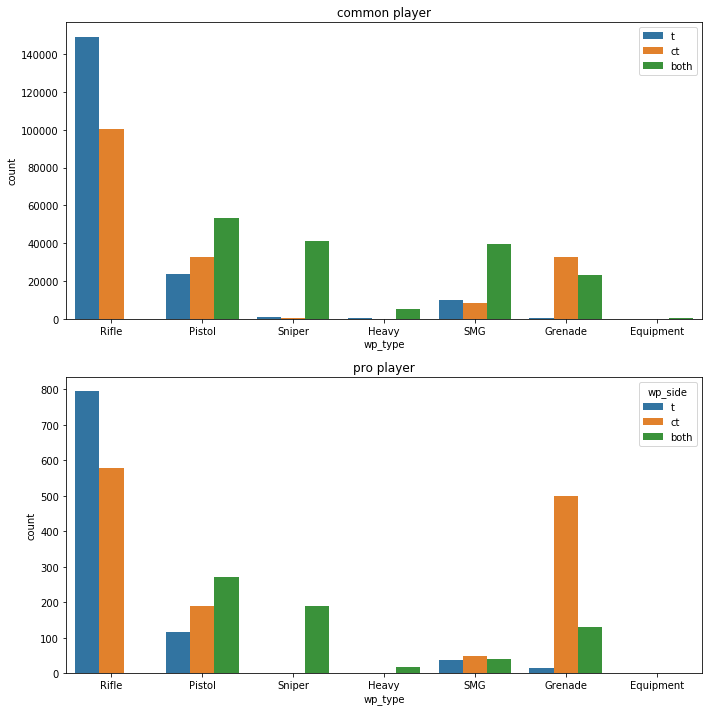

```python
#future development:see https://matplotlib.org/gallery/pie_and_polar_charts/polar_bar.html#sphx-glr-gallery-pie-and-polar-charts-polar-bar-py
f,a=plt.subplots(2,1,figsize=(10,10))
sns.countplot(x='wp_type', data=dmg_common,ax=a[0],order=['Rifle','Pistol','Sniper','Heavy','SMG','Grenade','Equipment'],hue='wp_side',hue_order=['t','ct','both']).set_title('common player')
a[0].legend(loc='upper right')
sns.countplot(x='wp_type', data=dmg_pro,ax=a[1],order=['Rifle','Pistol','Sniper','Heavy','SMG','Grenade','Equipment'],hue='wp_side',hue_order=['t','ct','both']).set_title('pro player')
plt.tight_layout()
```

*Summary of the weapon preference of professonal players and common players on general type:*

- Pro players use grenade more often than common players.
- Both common players and pro players have very similar preferences towards other weapon types.
- Rifle is the most popular type of weapon.

**2. weapon preference on detailed type**

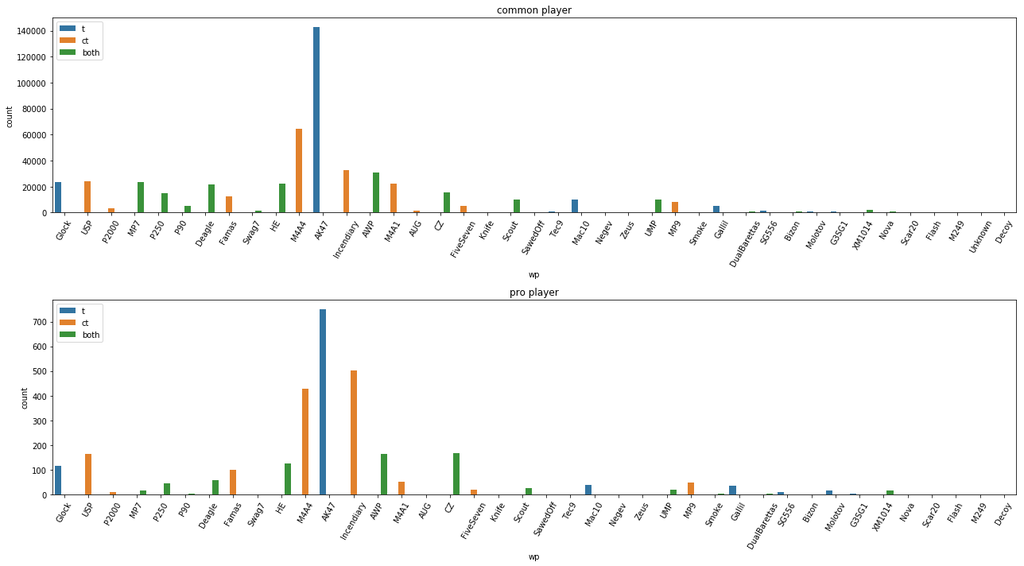

```python
#weapon preference(detailed)
f,a=plt.subplots(2,1,figsize=(18,10))
g=sns.countplot(x='wp', data=dmg_common,ax=a[0],order=list(dmg_common.wp.unique()),hue='wp_side',hue_order=['t','ct','both'])
g.set_title('common player')
g.set_xticklabels(g.get_xticklabels(),rotation=60)
a[0].legend(loc='upper left')

#remove Unknown type for current use
col_use=list(dmg_common.wp.unique())
col_use.pop(col_use.index('Unknown'))
g=sns.countplot(x='wp', data=dmg_pro,ax=a[1],order=col_use,hue='wp_side',hue_order=['t','ct','both'])
g.set_title('pro player')
g.set_xticklabels(g.get_xticklabels(),rotation=60)
a[1].legend(loc='upper left')
plt.tight_layout()
```

*Summary of the weapon preference of professonal players and common players on detailed type:*

- Both common players and pro players would like to use AK47 and M4A4 frequently.
- But pro player would also equip incendiary more often than M4A4, since incendiary is a more strategic weapon.

**3. weapon preference on detailed type in each category without considering pro player and com player**

As we have analyzed the weapon preference on an overview of category and on the detailed weapon chosen, we would like to see the detailed weapon choosen in each category.

```python
#weapon preference by category and detail type
wp_hier=dmg.set_index(['wp_type','wp'])
wp_hier_count=wp_hier.pivot_table(values=['round'],index=['wp_type','wp'],aggfunc='count')
```

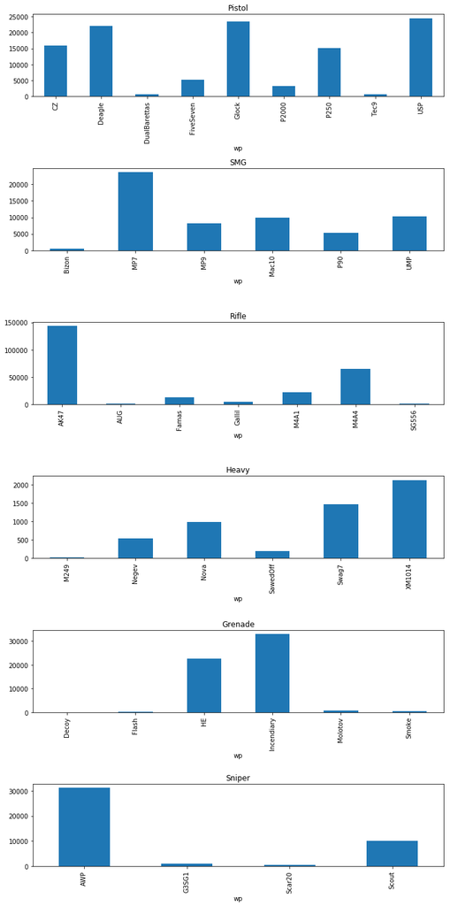

```python
#preference by weapon category
f,a=plt.subplots(6,1,figsize=(10,20))
wp_hier_count.xs('Pistol').plot(kind='bar',ax=a[0],title='Pistol',legend=False)
wp_hier_count.xs('SMG').plot(kind='bar',ax=a[1],title='SMG',legend=False)
wp_hier_count.xs('Rifle').plot(kind='bar',ax=a[2],title='Rifle',legend=False)
wp_hier_count.xs('Heavy').plot(kind='bar',ax=a[3],title='Heavy',legend=False)
wp_hier_count.xs('Grenade').plot(kind='bar',ax=a[4],title='Grenade',legend=False)
wp_hier_count.xs('Sniper').plot(kind='bar',ax=a[5],title='Sniper',legend=False)
plt.tight_layout()
```

*Summary of the weapon preference of professonal players and common players on detailed type in each category:*

- For Pistol category, deagle, glock and USP is more popular, but DualBarettas and Tec9 are barely used.
- For SMG category, players preder to use MP7, but rarely choose Bizon.
- For Rifle category, AK47 is the most popular one, but AUG, SG556 and Gallil are almost never choosen.
- For Heavy category, XM1014 is more likely to be used, but M249 is least likely.
- For Grenade category, increndiary is relatively much popular.
- For Sniper category, players would like to choose AWP, insteady of G35G1 and scar20.

In depth, the higher popularity of these listed weapon maybe because of the ease of collimation, the large damage produced, the large amount of bullet equiped, cost-effective price, etc.

## Question 2:

What are the different preference between common players and professional players, considering to analyze the hixbox?

### *The hitbox comparison of professional players and common players*

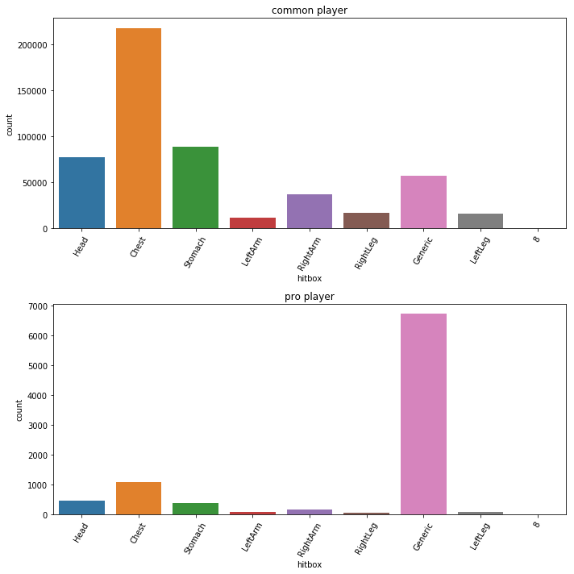

```python
#hitbox analysis
f,a=plt.subplots(2,1,figsize=(10,10))
g=sns.countplot(x='hitbox', data=dmg_common,ax=a[0],order=list(dmg.hitbox.unique()))
g.set_title('common player')
g.set_xticklabels(g.get_xticklabels(),rotation=60)

g=sns.countplot(x='hitbox', data=dmg_pro,ax=a[1],order=list(dmg.hitbox.unique()))
g.set_title('pro player')
g.set_xticklabels(g.get_xticklabels(),rotation=60)
plt.tight_layout()
```

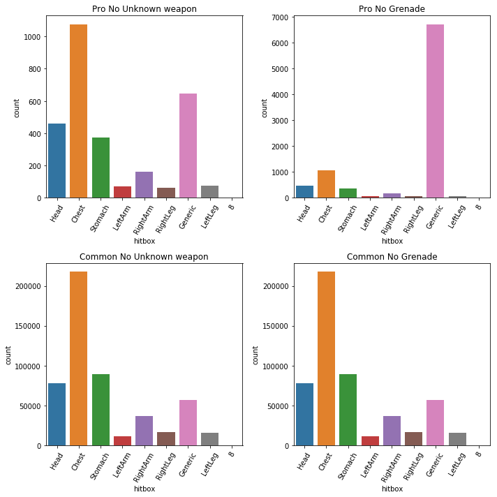

```python
#exclude certain factors
f,a=plt.subplots(2,2,figsize=(10,10))
g=sns.countplot(x='hitbox', data=dmg_pro[dmg_pro['wp']!='Unknown'],ax=a[0,0],order=list(dmg.hitbox.unique()))
g.set_title('Pro No Unknown weapon')
g.set_xticklabels(g.get_xticklabels(),rotation=60)

g=sns.countplot(x='hitbox', data=dmg_pro[dmg_pro['wp']!='Grenade'],ax=a[0,1],order=list(dmg.hitbox.unique()))
g.set_title('Pro No Grenade')
g.set_xticklabels(g.get_xticklabels(),rotation=60)
plt.tight_layout()

g=sns.countplot(x='hitbox', data=dmg_common[dmg_common['wp']!='Unknown'],ax=a[1,0],order=list(dmg.hitbox.unique()))
g.set_title('Common No Unknown weapon')
g.set_xticklabels(g.get_xticklabels(),rotation=60)

g=sns.countplot(x='hitbox', data=dmg_common[dmg_common['wp']!='Grenade'],ax=a[1,1],order=list(dmg.hitbox.unique()))
g.set_title('Common No Grenade')
g.set_xticklabels(g.get_xticklabels(),rotation=60)
plt.tight_layout()
```

*Summary of the hitbox comparison of professional players and common players:*

- For common players, most of the time, they hit chest.
- For pro player, most of the time they hit generic. This is not expected. Generic the biggest part for pro player, even if grenade damage is excluded.

## Question 3:

What are the most frequent spots under different situations? How do players use grenades? What are the different preference between common players and professional players, considering the bombing position, smoke landing position and attacking position?

### *Heatmap*

```python
# Position range of dust2 map
EndX=2127
EndY=3455
ResX=1024
ResY=1024
StartX=-2486
StartY=-1150
```

```python
## Calculate revised position on map
# damage dataframe
dmg['att_pos_x']=ResX*(dmg['att_pos_x']-StartX)/(EndX-StartX)
dmg['att_pos_y']=ResY*(dmg['att_pos_y']-StartY)/(EndY-StartY)
dmg['vic_pos_x']=ResX*(dmg['vic_pos_x']-StartX)/(EndX-StartX)
dmg['vic_pos_y']=ResY*(dmg['vic_pos_y']-StartY)/(EndY-StartY)
# grenade dataframe
grenade['att_pos_x']=ResX*(grenade['att_pos_x']-StartX)/(EndX-StartX)
grenade['att_pos_y']=ResY*(grenade['att_pos_y']-StartY)/(EndY-StartY)
grenade['nade_land_x']=ResX*(grenade['nade_land_x']-StartX)/(EndX-StartX)
grenade['nade_land_y']=ResY*(grenade['nade_land_y']-StartY)/(EndY-StartY)
grenade['vic_pos_x']=ResX*(grenade['vic_pos_x']-StartX)/(EndX-StartX)
grenade['vic_pos_y']=ResY*(grenade['vic_pos_y']-StartY)/(EndY-StartY)
```

```python
# Read background map image
dust2=plt.imread(path+'de_dust2.png')
```

```python
# Heatmap function
def heatmap(image,plot1_series_x,plot1_series_y,plot2_series_x,plot2_series_y,title1,title2,c1='YlOrBr',c2='Blues'):
    fig,axes=plt.subplots(1,2,figsize=(18,16))
    axes[0].imshow(image, zorder=0, extent=[0, 1024, 0, 1024])
    axes[1].imshow(image, zorder=0, extent=[0, 1024, 0, 1024])
    axes[0].axis('off')
    axes[1].axis('off')

    a='CT'
    b='B'

    sns.kdeplot(plot1_series_x, plot1_series_y, cmap=c1, bw=15, ax=axes[0])
    axes[0].set_title(title1,fontsize=18)
    axes[0].axis((0,1024,0,1024))
    axes[0].annotate('B',xy=(180,850),fontsize=22,fontweight='bold',color='white')
    axes[0].annotate('A',xy=(800,800),fontsize=22,fontweight='bold',color='white')
    axes[0].annotate(f'{a:^10}\nSPAWN',xy=(550,760),fontsize=14,fontweight='bold',color='white')
    axes[0].annotate('T SPAWN',xy=(290,55),fontsize=14,fontweight='bold',color='white')
    axes[0].annotate('LONG A',xy=(850,650),fontsize=22,fontweight='bold',color='white',rotation=270)
    axes[0].annotate('MID',xy=(420,500),fontsize=22,fontweight='bold',color='white',rotation=270)
    axes[0].annotate(' LONG\nDOORS',xy=(660,380),fontsize=12,fontweight='bold',color='white',rotation=270)
    axes[0].annotate('UPPER B',xy=(100,510),fontsize=14,fontweight='bold',color='white')
    axes[0].annotate('CT MID',xy=(270,760),fontsize=22,fontweight='bold',color='white')
    axes[0].annotate('A PLAT',xy=(680,850),fontsize=14,fontweight='bold',color='white')
    axes[0].annotate(f'{b:^7}\nPLAT',xy=(60,850),fontsize=14,fontweight='bold',color='white')
    axes[0].annotate(f'DOOR\n{b:^9}',xy=(60,610),fontsize=14,fontweight='bold',color='white')
    axes[0].annotate('  MID\nDOOR',xy=(400,610),fontsize=12,fontweight='bold',color='white')

    sns.kdeplot(plot2_series_x, plot2_series_y, cmap=c2, bw=15, ax=axes[1])
    axes[1].set_title(title2,fontsize=18)
    axes[1].axis((0,1024,0,1024))
    axes[1].annotate('B',xy=(180,850),fontsize=22,fontweight='bold',color='white')
    axes[1].annotate('A',xy=(800,800),fontsize=22,fontweight='bold',color='white')
    axes[1].annotate(f'{a:^10}\nSPAWN',xy=(550,760),fontsize=14,fontweight='bold',color='white')
    axes[1].annotate('T SPAWN',xy=(290,55),fontsize=14,fontweight='bold',color='white')
    axes[1].annotate('LONG A',xy=(850,650),fontsize=22,fontweight='bold',color='white',rotation=270)
    axes[1].annotate('MID',xy=(420,500),fontsize=22,fontweight='bold',color='white',rotation=270)
    axes[1].annotate(' LONG\nDOORS',xy=(660,380),fontsize=12,fontweight='bold',color='white',rotation=270)
    axes[1].annotate('UPPER B',xy=(100,510),fontsize=14,fontweight='bold',color='white')
    axes[1].annotate('CT MID',xy=(270,760),fontsize=22,fontweight='bold',color='white')
    axes[1].annotate('A PLAT',xy=(680,850),fontsize=14,fontweight='bold',color='white')
    axes[1].annotate(f'{b:^7}\nPLAT',xy=(60,850),fontsize=14,fontweight='bold',color='white')
    axes[1].annotate(f'DOOR\n{b:^9}',xy=(60,610),fontsize=14,fontweight='bold',color='white')
    axes[1].annotate('  MID\nDOOR',xy=(400,610),fontsize=12,fontweight='bold',color='white')
```

**1. Attacking position heatmap**

[figure not shown]

```python
# Create 1X2 subplots
plot_df1 = dmg.loc[(dmg.att_side == 'Terrorist')]
plot_df2 = dmg.loc[(dmg.att_side == 'CounterTerrorist')]
heatmap(dust2,plot_df1['att_pos_x'],plot_df1['att_pos_y'],plot_df2['att_pos_x'],plot_df2['att_pos_y'],
        'Terrorists Attacking','Counter-Terrorists Attacking')
```

*Summary of attacking position heatmap:*

These two graphs are general attacking position heatmaps. The left graph represents terrorists and the right graph represents counter-terrorists. For a position on map, the denser the surrounding lines are, the more frequent attacks happen.  
We can see the primary battlefield is the place between Long A and Long Doors. It is worth noticing that terrorists have 5 concentrated attacking positions. Apart from Long Doors, terrorists also have preference on Mid Doors, Door B, T Spawn and CT Spawn. Unlike terrorists, counter-terrorists tend to attack from scattered positions.

**2. Attacking position heatmap during pistol round**

[figure not shown]

```python
plot_df1 = dmg.loc[(dmg.att_side == 'Terrorist') & (dmg.round_type == 'PISTOL_ROUND')]
plot_df2 = dmg.loc[(dmg.att_side == 'CounterTerrorist') & (dmg.round_type == 'PISTOL_ROUND')]
heatmap(dust2,plot_df1['att_pos_x'],plot_df1['att_pos_y'],plot_df2['att_pos_x'],plot_df2['att_pos_y'],
        'Terrorists Pistol Round Attacking','Counter-Terrorists Pistol Round Attacking')
```

*Summary of attacking position heatmap during pistol round:*

These two graphs are attacking position heatmaps during pistol round.  
Compared to overall attacking position heatmaps of all types of round, the distribution of attacking positions for terrorist side is more scattered while the distribution of counter-terrorist attacking position is more concentrative. According to the right graph, Counter-terrorists have heavy preference on B side and the bottom left of CT Mid. But they usually don't wait at A PLAT and LONG A to defend A side. Heavily attacking A side might be a wise choice for terrorists.

**3. Sniper attacking position heatmap**

[figure not shown]

```python
plot_df1 = dmg.loc[(dmg.att_side == 'Terrorist') & (dmg.wp_type == 'Sniper')]
plot_df2 = dmg.loc[(dmg.att_side == 'CounterTerrorist') & (dmg.wp_type == 'Sniper')]
heatmap(dust2,plot_df1['att_pos_x'],plot_df1['att_pos_y'],plot_df2['att_pos_x'],plot_df2['att_pos_y'],
        'Terrorists Sniper Attacking','Counter-Terrorists Sniper Attacking')
```

*Summary of sniper attacking position heatmap:*

These two graphs are sniper attacking position heatmaps. They tell us where does a sniper usually attack from.  
From the left heatmap, we can see that terrorist sniper usually aims at Mid from the right of T Spawn. And counter-terrorist sniper usually locates at the right of CT MID. It is likely that both sides will set a sniper at mid-way during a game. When a player attempts to accross Mid, it would better throw a smoke or covered by teammates.

**4. Smoke landing position heatmap**

[figure not shown]

```python
plot_df1 = grenade.loc[(grenade.att_side == 'Terrorist') & (grenade.nade == 'Smoke')]
plot_df2 = grenade.loc[(grenade.att_side == 'CounterTerrorist') & (grenade.nade == 'Smoke')]
heatmap(dust2,plot_df1['nade_land_x'],plot_df1['nade_land_y'],plot_df2['nade_land_x'],plot_df2['nade_land_y'],
        'Terrorists Smoke landing','Counter-Terrorists Smoke landing')
```

*Summary of smoke landing position heatmap:*

These two graphs are smoke landing position heatmaps. Smoke is a useful grenade to avoid damage and to control areas of the map.  
The heatmaps represent the frequency of smoke landing thrown by terrorists and counter-terrorists. It is obvious that smoke landing positions are concentrative. For terrorists, they tend to throw grenades at Left CT MID, Mid Doors and A side. For counter-terrorists, they tend to throw grenades at Door B, Right CT MID and Long Doors.

**5. Attacking position heatmap under counter-terrorists eco-advantage round**

[figure not shown]

```python
plot_df1 = dmg.loc[(dmg.att_side == 'Terrorist') & ((dmg.ct_eq_val-dmg.t_eq_val)>10000)]
plot_df2 = dmg.loc[(dmg.att_side == 'CounterTerrorist') & ((dmg.ct_eq_val-dmg.t_eq_val)>10000)]
heatmap(dust2,plot_df1['att_pos_x'],plot_df1['att_pos_y'],plot_df2['att_pos_x'],plot_df2['att_pos_y'],
        'Terrorists Attacking','Counter-Terrorists Attacking')
```

**6. Attacking position heatmap under terrorists eco-advantage round**

[figure not shown]

```python
plot_df1 = dmg.loc[(dmg.att_side == 'Terrorist') & ((dmg.t_eq_val-dmg.ct_eq_val)>10000)]
plot_df2 = dmg.loc[(dmg.att_side == 'CounterTerrorist') & ((dmg.t_eq_val-dmg.ct_eq_val)>10000)]
heatmap(dust2,plot_df1['att_pos_x'],plot_df1['att_pos_y'],plot_df2['att_pos_x'],plot_df2['att_pos_y'],
        'Terrorists Attacking','Counter-Terrorists Attacking')
```

*Attacking position heatmap under counter-terrorists eco-advantage round:*

Upper two heatmaps show frequent attacking positions when counter-terrorist team's total equipment value is over 10000 larger than terrorist team's. Bottom two heatmaps show frequent attacking positions when terrorist team's total equipment value is over 10000 larger than counter-terrorist team's. Comparing these heatmaps, we can notice that when counter-terrorist team has eco-advantage, terrorist team is more likely to attack Mid Door while terrorist team avoids attacking from Mid Door when it possesses eco-advantage. We also infer that when terrorist team is economically disadvantaged, it tends to attack B side. But when it is economically advantaged, it tends to attack A side. Counter-terrorist team could have an expectation of the side terrorists attack if they calculate the economy difference in advance.

**7. Counter-Terrorists Attacking Bomb A heatmap**

[figure not shown]

```python
plot_df1 = dmg.loc[(dmg.att_side == 'CounterTerrorist') & (dmg.pro_game == 1) & (dmg.bomb_site == 'A')]
plot_df2 = dmg.loc[(dmg.att_side == 'CounterTerrorist') & (dmg.pro_game == 0) & (dmg.bomb_site == 'A')]
heatmap(dust2,plot_df1['att_pos_x'],plot_df1['att_pos_y'],plot_df2['att_pos_x'],plot_df2['att_pos_y'],
        'Counter-Terrorists Attacking Bomb A (professional)','Counter-Terrorists Attacking Bomb A (common)',c1='Blues')
```

*Summary of Counter-Terrorists Attacking Bomb A heatmap:*

These two graphs show how counter terrorists attack after the bomb is planted at A side. The left graph represents professional players and the right graph represents common players.  
According to the heatmaps, professional and common players have different attacking strategies after the bomb is planted at A side. Professional players tend to attack from Long A while common players tend to attack from CT Spawn. But we can also notice that professional teams usually set a sniper at CT Mid. So actually they attack A side from two sides instead of one. Here is a situation that the tactics of professional teams and common teams differ. If you are a common player who wants to improve performance, learning tactics from professional teams might be a good choice. For this situation, playing like a professional team requires strict timing coordination. You have to pratice a lot with your teammates to play a good match.

## Question 4:

What are the factors which influence the winning probability of Counterterrorist and Terrorist? Does the type of round, the bombing planting, team wealth are important elements to win?

The following analysis will primarily use the dataframe **round_infor** created in preprocess part.

```python
round_infor.head()
```

|  | file | round | start_seconds | end_seconds | winner_team | winner_side | round_type | ct_eq_val | t_eq_val | seconds | bomb_site | pro_game | ct_alive | t_alive |
| --- | --- | --- | --- | --- | --- | --- | --- | --- | --- | --- | --- | --- | --- | --- |
| 160 | esea_match_13779825.dem | 1 | 131.3593 | 233.1502 | Team 1 | CounterTerrorist | PISTOL_ROUND | 4400 | 3700 | 96.7507 | Not Plant | 0 | 3 | 0 |
| 328 | esea_match_13779825.dem | 2 | 233.1502 | 296.1376 | Team 1 | CounterTerrorist | ECO | 18700 | 4050 | 57.9784 | Not Plant | 0 | 3 | 0 |
| 438 | esea_match_13779825.dem | 3 | 296.1376 | 373.3534 | Team 1 | CounterTerrorist | ECO | 22100 | 1600 | 72.1756 | Not Plant | 0 | 4 | 1 |
| 862 | esea_match_13779825.dem | 4 | 373.3534 | 614.6275 | Team 2 | Terrorist | NORMAL | 28250 | 20650 | 236.2496 | B | 0 | 0 | 2 |
| 974 | esea_match_13779825.dem | 5 | 614.6275 | 671.1659 | Team 1 | CounterTerrorist | FORCE_BUY | 10250 | 21150 | 51.4981 | Not Plant | 0 | 2 | 0 |

### *The winning probability based on the round type*

Analyze the winning probability under each round condition, conditions that include the round type(ECO, FORCE_BUY, NORMAL, PISTOL_ROUND and SEMI_ECO).

```python
#winning rate by round type
round_infor['map']='dust2'
roundtype_win = round_infor.groupby(['file', 'round', 'round_type', 'winner_side','map'])['start_seconds'].first().groupby(['map','round_type', 'winner_side']).count()
roundtype_win_pct = roundtype_win.groupby(level=[0,1]).apply(lambda x: 100 * x / float(x.sum()))
roundtype_win_pct.unstack('map')
```

| round_type | map winner_side | dust2 |
| --- | --- | --- |
| ECO | CounterTerrorist | 44.224568 |
|  | Terrorist | 55.775432 |
| FORCE_BUY | CounterTerrorist | 46.361301 |
|  | Terrorist | 53.638699 |
| NORMAL | CounterTerrorist | 47.908232 |
|  | Terrorist | 52.091768 |
| PISTOL_ROUND | CounterTerrorist | 46.282051 |
|  | Terrorist | 53.717949 |
| SEMI_ECO | CounterTerrorist | 44.837758 |
|  | Terrorist | 55.162242 |

For better comparison, we made a barchart to see the difference of winning probability of various round type for CT and T.

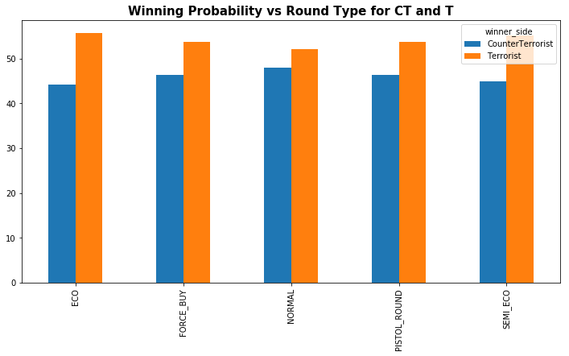

```python
#winning rate by round type
roundtype_win_pct.unstack(2).plot(kind='bar', figsize=(12,6))
plt.xticks(np.arange(5), ('ECO','FORCE_BUY','NORMAL','PISTOL_ROUND','SEMI_ECO'))
plt.xlabel('');
plt.title('Winning Probability vs Round Type for CT and T', fontweight='bold', fontsize=15)
```

*Summary of winning probability vs Round Type and Bomb Site for CT and T:*

This graph shows that in this dataset, the terrorist is more likely to win no matter what type of the round is. But when taking insights of it, if the round type is ECO and SEMI_ECO, the terrorist has relatively more probabilities to win the round. So terrorist has to seize the opportunity when it is a ECO or SEMI_ECO round.

### *The winning probability affected by the site where bomb is planted, considering both CT side and T side*

```python
#winning rate by bomb_site
dmg['map']='dust2'
bomb_win = dmg.groupby(['file', 'round', 'bomb_site', 'winner_side','map'])['start_seconds'].first().groupby(['map','bomb_site', 'winner_side']).count()
bomb_win_pct = bomb_win.groupby(level=[0,1]).apply(lambda x: 100 * x / float(x.sum()))
bomb_win_pct.unstack('map')
```

| bomb_site | map winner_side | dust2 |
| --- | --- | --- |
| A | CounterTerrorist | 20.836286 |
|  | Terrorist | 79.163714 |
| B | CounterTerrorist | 19.679962 |
|  | Terrorist | 80.320038 |
| Not Plant | CounterTerrorist | 46.212121 |
|  | Terrorist | 53.787879 |

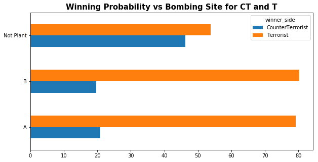

```python
bomb_win_pct.unstack(2).plot.barh(figsize=(10,5))
plt.yticks(np.arange(3), ('A','B','Not Plant'))
plt.ylabel('');
plt.title('Winning Probability vs Bombing Site for CT and T', fontweight='bold', fontsize=15)
```

*Summary of the winning probability affected by the site where bomb is planted, considering both CT side and T side:*

- If bomb is not planted, the chance of win is slightly higher for Terrorist.
- If bomb is planted, the chance of win for T increases by a huge percentage.

### *The winning probability affected by Wealth Difference*

```python
spend=pd.DataFrame().assign(winner=round_infor['winner_side'],
                            wealth_difference=round_infor['ct_eq_val']-round_infor['t_eq_val'])
spend=spend.assign(wealth_difference=spend.apply(lambda x: x.wealth_difference if x.winner=='CounterTerrorist' else -x.wealth_difference,axis='columns'),
                   winner=spend.winner.map(lambda y: True if y=='CounterTerrorist' else False))
spend=spend.assign(wealth_difference_bin=pd.qcut(spend.wealth_difference,10)).groupby('wealth_difference_bin').apply(lambda z: z.winner.sum()/len(z.winner))
spend.index=spend.index.values.map(lambda cen: cen.left + (cen.right-cen.left)/2).astype(int)
```

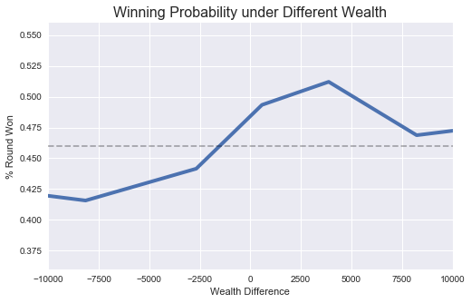

```python
plt.style.use('seaborn');
fig = plt.figure(figsize=(8,5));
spend.plot.line(linewidth=4);
plt.title("Winning Probability under Different Wealth",fontsize=16);
ax = plt.gca();
ax.axhline(0.46,linestyle='--',color='black',alpha=0.3);
ax.set_xlim([-10000,10000]);
ax.set_ylim([0.36, 0.56]);
ax.set_xlabel('Wealth Difference');
ax.set_ylabel('% Round Won');
```

*Summary of the winning probability affected by Wealth Difference:*

The average winning probability for Counter-Terrorists at the map 'dust II' is 46.0%. The line chart above shows how Wealth Difference (CT's total equipment value - T's total equipment value) affects winning probability. In general, when the wealth of a side increases, the winning probability grows higher. When Counter-Terrorists and Terrorists have the same equipment value, Counter-Terrorists have 48.5% probability to win.

## Conclusion

**After doing all the visualization and analysis, we have several suggestions for common players:**

1. Buying Strategy:
   - Buy more props and utilities (CT side). Pro players tends to use more props than common players. This game is not all about shooting but also about strategies.
   - Weapon: Actually there is not a great variance in weapon preference between common players and pro players. We recommend use whatever you are familiar with. Generally, more expensive the weapon you have, the higher probability your team has to win
2. Positioning strategy:
   - Try attack one side through different routes. Learn from pro teams and practise more with teammates to find out the best time for attacking. Timing is especially crucial after bomb is planted.
   - Try avoid stand still at the most dangerous positions (e.g Mid Door, Long A, Door B) at the beginning (when common players are most likely to use props such as incendiary).
   - Develop corresponding tactics for different situations. For instance, terrorists would better attack A side during pistol round.
3. Bomb Planting strategy:
   - Two bomb sites have similar winning probability for terrorist. As terrorist, choose either is fine. If in a ECO and round, try everything to plant the bomb because in that way, it will maximize the team wealth the most.

**Final words and future work:**

As we work on the projects, we began to find more and more interesting points on some details in the dataset, different from how we began (we tried to think about what big issues we could find and solve). Somehow, this project makes us change our opinions on data analysis, to some extent. That is, sometimes valuable points lie in small details. We would go deeper into specific area rather than covering as much as we can in the future.